# TMDB Movie Dataset

- Introduction
- Data Wrangling
- Data Cleaning
- Exploratory Data Analysis
- Conclusions
- Limitations

## Introduction

TMDB Movie dataset contains details about 10867 movies ranging from the year 1960 to 2015. It contains details such as the movie name, director,production companies, release year, runtime, budget,revenue etc. This details are taken into consideration by me inorder to visualize the aspects that the data has in store for us. So we will start the analysis by loading the CSV file into the jupyter notebook using pandas library. Pandas,Numpy and matplotlib are the libraries used for carrying out the process. Numpy's usage will be less as Pandas makes up a significant portion of the coding. Lets dive into what i found.

```python
# Import of packages takes place in this cell. The plots are made to stay inline.
import numpy as np
import pandas as pd
import matplotlib.pyplot as plt
%matplotlib inline
```

## Data Wrangling

The 'tmdb-movies.CSV' file is loaded into the pandas dataframe 'mov'. The loaded Dataframe is then checked for its size,description of columns and their associated number of records with their object type.

### General Properties

```python
# Data in the form of CSV is loaded into a DataFrame.
mov=pd.read_csv('tmdb-movies.csv')
```

```python
#Checking for the information about the data.
mov.info()
```

[output not shown]

```python
#Checking for the shape of the entire dataset.
mov.shape
```

[output not shown]

```python
#Displaying the top records in data to get an overview of what it contains.
mov.head()
```

|  | id | imdb_id | popularity | budget | revenue | original_title | cast | homepage | director | tagline | ... | overview | runtime | genres | production_companies | release_date | vote_count | vote_average | release_year | budget_adj | revenue_adj |
| --- | --- | --- | --- | --- | --- | --- | --- | --- | --- | --- | --- | --- | --- | --- | --- | --- | --- | --- | --- | --- | --- |
| 0 | 135397 | tt0369610 | 32.985763 | 150000000 | 1513528810 | Jurassic World | Chris Pratt\|Bryce Dallas Howard\|Irrfan Khan\|Vi... | http://www.jurassicworld.com/ | Colin Trevorrow | The park is open. | ... | Twenty-two years after the events of Jurassic ... | 124 | Action\|Adventure\|Science Fiction\|Thriller | Universal Studios\|Amblin Entertainment\|Legenda... | 06-09-2015 | 5562 | 6.5 | 2015 | 137999939.3 | 1.392446e+09 |
| 1 | 76341 | tt1392190 | 28.419936 | 150000000 | 378436354 | Mad Max: Fury Road | Tom Hardy\|Charlize Theron\|Hugh Keays-Byrne\|Nic... | http://www.madmaxmovie.com/ | George Miller | What a Lovely Day. | ... | An apocalyptic story set in the furthest reach... | 120 | Action\|Adventure\|Science Fiction\|Thriller | Village Roadshow Pictures\|Kennedy Miller Produ... | 5/13/15 | 6185 | 7.1 | 2015 | 137999939.3 | 3.481613e+08 |
| 2 | 262500 | tt2908446 | 13.112507 | 110000000 | 295238201 | Insurgent | Shailene Woodley\|Theo James\|Kate Winslet\|Ansel... | http://www.thedivergentseries.movie/#insurgent | Robert Schwentke | One Choice Can Destroy You | ... | Beatrice Prior must confront her inner demons ... | 119 | Adventure\|Science Fiction\|Thriller | Summit Entertainment\|Mandeville Films\|Red Wago... | 3/18/15 | 2480 | 6.3 | 2015 | 101199955.5 | 2.716190e+08 |
| 3 | 140607 | tt2488496 | 11.173104 | 200000000 | 2068178225 | Star Wars: The Force Awakens | Harrison Ford\|Mark Hamill\|Carrie Fisher\|Adam D... | http://www.starwars.com/films/star-wars-episod... | J.J. Abrams | Every generation has a story. | ... | Thirty years after defeating the Galactic Empi... | 136 | Action\|Adventure\|Science Fiction\|Fantasy | Lucasfilm\|Truenorth Productions\|Bad Robot | 12/15/15 | 5292 | 7.5 | 2015 | 183999919.0 | 1.902723e+09 |
| 4 | 168259 | tt2820852 | 9.335014 | 190000000 | 1506249360 | Furious 7 | Vin Diesel\|Paul Walker\|Jason Statham\|Michelle ... | http://www.furious7.com/ | James Wan | Vengeance Hits Home | ... | Deckard Shaw seeks revenge against Dominic Tor... | 137 | Action\|Crime\|Thriller | Universal Pictures\|Original Film\|Media Rights ... | 04-01-2015 | 2947 | 7.3 | 2015 | 174799923.1 | 1.385749e+09 |

5 rows × 21 columns

### Data Cleaning

Data Cleaning is an important stage in this analysis process.Initially i am going to drop the columns which do not have any scope for analysis here. So i am going to drop the unwanted columns id,imdb_id,homepage,tagline,keywords,overview,release_date. These might be of some use to others but i am going to drop them as i dont have any analysis done for them. Finally, I am going to clean the fresh dataset with the columns dropped by checking for missing records, null values, conversion of data types and also replacing the budget and revenue data types.

```python
# Dropping the Unused Columns in the dataset and storing it in the same dataframe.
mov.drop(['id','imdb_id','homepage','tagline','keywords','overview','release_date'],axis=1,inplace=True)
```

```python
#Viewing one record to find the changes made.
mov.head(1)
```

|  | popularity | budget | revenue | original_title | cast | director | runtime | genres | production_companies | vote_count | vote_average | release_year | budget_adj | revenue_adj |
| --- | --- | --- | --- | --- | --- | --- | --- | --- | --- | --- | --- | --- | --- | --- |
| 0 | 32.985763 | 150000000 | 1513528810 | Jurassic World | Chris Pratt\|Bryce Dallas Howard\|Irrfan Khan\|Vi... | Colin Trevorrow | 124 | Action\|Adventure\|Science Fiction\|Thriller | Universal Studios\|Amblin Entertainment\|Legenda... | 5562 | 6.5 | 2015 | 137999939.3 | 1.392446e+09 |

```python
#Removing Duplicate records present in the dataset.
mov.drop_duplicates(keep='first',inplace = True)
```

```python
#Replacing Budget column records which had zero with NAN.
mov['budget']=mov['budget'].replace(0,np.NAN)
```

```python
#Replacing Revenue column records which had zero with NAN.
mov['revenue']=mov['revenue'].replace(0,np.NAN)
```

```python
#Keeping the budget and revenue as a subset and dropping the records which have NAN as a value in the budget or revenue column.
rem=['budget','revenue']
mov.dropna(subset=rem,inplace=True)
```

```python
#Converting Revenue to float.
mov['revenue'] = mov['revenue'].apply(lambda x: '{:.2f}'.format(x))
```

```python
mov.revenue=mov.revenue.astype(float)
```

```python
mov.budget=mov.budget.astype(float)
```

```python
#Converting budget and revenue into Int datatype to perform analysis easily.
kn=['budget','revenue']
mov[kn]=mov[kn].applymap(np.int64)
```

```python
#Describing the Cleaned Dataset to find out essential information.
mov.describe()
```

|  | popularity | budget | revenue | runtime | vote_count | vote_average | release_year | budget_adj | revenue_adj |
| --- | --- | --- | --- | --- | --- | --- | --- | --- | --- |
| count | 3854.000000 | 3.854000e+03 | 3.854000e+03 | 3854.000000 | 3854.000000 | 3854.000000 | 3854.000000 | 3.854000e+03 | 3.854000e+03 |
| mean | 1.191554 | 3.720370e+07 | 1.076866e+08 | 109.220291 | 527.720291 | 6.168163 | 2001.261028 | 4.423999e+07 | 1.370647e+08 |
| std | 1.475162 | 4.220822e+07 | 1.765393e+08 | 19.922820 | 879.956821 | 0.794920 | 11.282575 | 4.480925e+07 | 2.161114e+08 |
| min | 0.001117 | 1.000000e+00 | 2.000000e+00 | 15.000000 | 10.000000 | 2.200000 | 1960.000000 | 9.693980e-01 | 2.370705e+00 |
| 25% | 0.462368 | 1.000000e+07 | 1.360003e+07 | 95.000000 | 71.000000 | 5.700000 | 1995.000000 | 1.309053e+07 | 1.835735e+07 |
| 50% | 0.797511 | 2.400000e+07 | 4.480000e+07 | 106.000000 | 204.000000 | 6.200000 | 2004.000000 | 3.001611e+07 | 6.173068e+07 |
| 75% | 1.368324 | 5.000000e+07 | 1.242125e+08 | 119.000000 | 580.000000 | 6.700000 | 2010.000000 | 6.061307e+07 | 1.632577e+08 |
| max | 32.985763 | 4.250000e+08 | 2.781506e+09 | 338.000000 | 9767.000000 | 8.400000 | 2015.000000 | 4.250000e+08 | 2.827124e+09 |

## Exploratory Data Analysis

Now I have loaded the Data into a Dataframe, Analysed the dataframe's shape and what they contain, Dropped unused columns and trimmed the records which had Nan values. I am moving on to the Exploratory Data Analysis section as I possess a clean and clear dataset in my hands. Now I am going to start the process of Analysing Different areas from the given dataset.

## Question:

## How to find the Best Ingredients to make a Commercially Hit Movie?

## Movie Reviews

Reviews play an important role in boosting the success of a film. Lets consider the Internet Revolutionised 20th century. Nowadays when a movie is released,people tend to look at the review ratings of a movie before thinking of booking tickets for the same. So movies with higher review ratings tend to rake in more number of movie goers than a movie which is lowly rated. Thus we take a look into the number of movies and their corresponding review ratings. It is also interesting to find out which movie is highly reviewed and which has a low review rating.

```python
# This function helps in finding out the highest and lowest reviewed movie.
def code(mov):
    #Highest Reviewed Movie In IMDB
    mov=mov.sort_values(by='vote_count',ascending=False)
    vote = mov.iloc[0]
    print('\n Highest Reviewed Movie: \n')
    print(vote)
    #Lowest Reviewed Movie In IMDB
    mov=mov.sort_values(by='vote_count',ascending=True)
    vote_min=mov.iloc[0]
    print('\n Lowest Reviewed Movie: \n')
    print(vote_min)
```

```python
#Calling the function.
code(mov)
```

[output not shown]

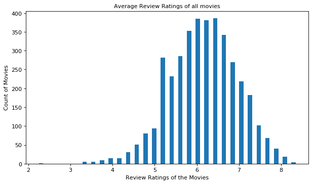

```python
#Plotting of the averages of view count against the number of movies
plt.figure(figsize=(9,5), dpi = 80)
#Label of X-Axis.
plt.xlabel('Review Ratings of the Movies', fontsize = 10)
#Label of Y-Axis.
plt.ylabel('Count of Movies', fontsize=10)
#Title of the Graph
plt.title('Average Review Ratings of all movies', fontsize=10)
#Plotting of the vote_average
plt.hist(mov['vote_average'], rwidth = 0.5, bins =30)
plt.show()
```

```python
# Using mov_new1 to store the records which are grouped by the runtime's mean.
mov_new1 = mov.groupby('runtime').mean()
```

```python
#Describing the new dataframe mov_new1
mov_new1.describe()
```

|  | popularity | budget | revenue | vote_count | vote_average | release_year | budget_adj | revenue_adj |
| --- | --- | --- | --- | --- | --- | --- | --- | --- |
| count | 139.000000 | 1.390000e+02 | 1.390000e+02 | 139.000000 | 139.000000 | 139.000000 | 1.390000e+02 | 1.390000e+02 |
| mean | 1.539126 | 4.640010e+07 | 1.626345e+08 | 822.907296 | 6.565067 | 1997.054938 | 6.219228e+07 | 2.284544e+08 |
| std | 1.340340 | 3.641385e+07 | 2.219365e+08 | 1008.665685 | 0.580480 | 10.650039 | 4.372090e+07 | 2.900828e+08 |
| min | 0.142836 | 1.000000e+01 | 3.000000e+00 | 10.000000 | 5.200000 | 1961.000000 | 1.185353e+01 | 3.038360e+00 |
| 25% | 0.897339 | 2.683125e+07 | 6.013901e+07 | 298.684461 | 6.103247 | 1996.312500 | 3.480045e+07 | 8.740560e+07 |
| 50% | 1.167031 | 3.700000e+07 | 9.713266e+07 | 503.777778 | 6.583333 | 2000.384615 | 5.080069e+07 | 1.423509e+08 |
| 75% | 1.598825 | 5.860206e+07 | 1.752603e+08 | 922.519048 | 6.900000 | 2002.354167 | 8.169521e+07 | 2.888000e+08 |
| max | 9.075899 | 2.070000e+08 | 1.845034e+09 | 5636.000000 | 8.100000 | 2013.000000 | 2.716921e+08 | 2.506406e+09 |

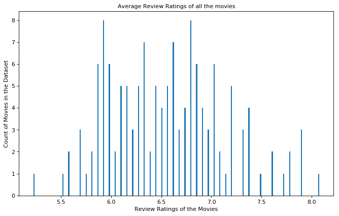

```python
#Plotting of review ratings takes place.
plt.figure(figsize=(10,6), dpi = 80)
#Label on X-Axis
plt.xlabel('Review Ratings of the Movies', fontsize = 10)
#Label on Y-Axis
plt.ylabel('Count of Movies in the Dataset', fontsize=10)
#Title of the Graph
plt.title('Average Review Ratings of all the movies', fontsize=10)
#Plotting of the vote_average
plt.hist(mov_new1['vote_average'], rwidth = 0.2, bins =50)
plt.show()
```

## Movies with Higher and Lower Profits

Profits play a crucial role in bringing a smile on everyone associated with making a film. Thus to support that fact I am adding a column into the dataframe named Profits which is a calculation of the values from budget and revenue.I am interested in finding out which movie netted the highest profit and which had a lower one. Movie's Success is mainly measured by the profit they achieve at the box office.

```python
#Inserting a new column Profit which is equal to revenue - budget
mov.insert(4, 'profit', mov['revenue'] - mov['budget'])
```

```python
#Function to find out the highest profit and the lowest profit.
def profits(mov):
    #Highest Reviewed Movie In IMDB
    mov=mov.sort_values(by='profit',ascending=False)
    profit = mov.iloc[0]
    print('\n Movie with Highest Profit:- \n')
    print(profit)
    #Lowest Reviewed Movie In IMDB
    mov=mov.sort_values(by='profit',ascending=True)
    profit_min=mov.iloc[0]
    print('\n Movie with Lowest Profit:- \n')
    print(profit_min)
```

```python
profits(mov)
```

[output not shown]

## Best of the Rest

High Quality Ingredients make a dish tasty. Likewise, Quality staff's are required to make a movie a commercial success. I am curious to know which Production houses, Directors and Cast have the ability to be successfull on a higher scale by giving movies which rake in a higher revenue than the budget spent on that movie. So I am making a new dataframe which stores the records that has a revenue more than the budget allocated to it. I am going to use this data frame to find out my required details and use it to visualize the data for a better understanding. Lets dig in!

```python
#Creating a new dataframe to store the records which contain more revenue when compared to the budget.
mov_new = mov[mov['revenue'] >= mov['budget']]
```

```python
#Finding out the shape of the new data frame.
mov_new.shape
```

```
(2782, 15)
```

```python
#This is a common function which splits the appended string into seperate values which helps in finding the desired results.
def seperator(column_name):
    #Takes column as input and seperates the string with |.
    sep = mov_new[column_name].str.cat(sep = '|')
    sep= pd.Series(sep.split('|'))
    count = sep.value_counts(ascending = False)
    return count
```

```python
# Passing 'production_companies' as the column and getting the top 5 results.
seperator('production_companies').head()
```

```
Universal Pictures                        269
Warner Bros.                              250
Paramount Pictures                        221
Twentieth Century Fox Film Corporation    173
Columbia Pictures                         150
dtype: int64
```

Any marketable product in this world is considered as a success only when the amount earned is more than the amount invested for the production. Likewise, A movie is set to be a hit only when the amount it makes at the Box office is more than the budget at which it is produced which results in the Production companies breathing easier. When a movie fails at the Box office, Production Companies are the sole losers in terms of money. Thus in this movie list, Universal Pictures were found to be the masters of the art of producing a movie as they had 269 hits compared to other production houses. Warnes Bros also rakes in 250 hit movies but just misses out on the edge that Universal Pictures seem to have.

```python
seperator('director').head()
```

```
Steven Spielberg    27
Clint Eastwood      21
Tim Burton          16
Ridley Scott        16
Robert Zemeckis     15
dtype: int64
```

Directors are the most important element for a movie to be an absolute blockbuster in the box office. It is also important for a director to be successfull in what he does. Steven Spielberg seems to have the mojo of winnning with 27 of his movies garnering a revenue amount more than the budget amount. Production Companies will be so interested in enquiring about Steven Spielberg's availability.

```python
seperator('cast').head()
```

```
Robert De Niro       38
Bruce Willis         33
Tom Hanks            33
Tom Cruise           31
Samuel L. Jackson    30
dtype: int64
```

Cast plays an important role in crowd pulling. Film's Success rate is mostly credited to the performance of the cast and there are actors who have the capability to influence a larger section of the movie goers. Robert De Niro tops the list for most successfull movies with a count of 38. Bruce willis and Tom hanks share the spoils with a count of 33. No doubt these actors will be on the radar of every director willing to make a successful film.

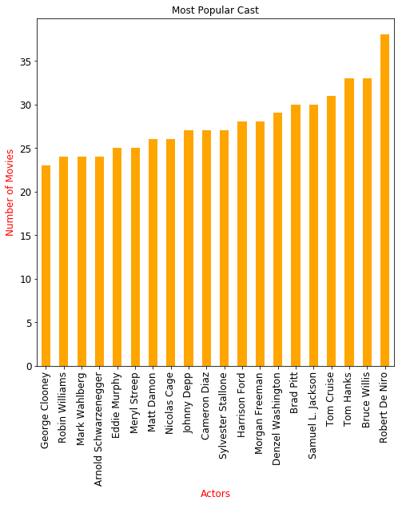

```python
cast_new= seperator('cast').head(20)
cast_new.sort_values(ascending = True, inplace = True)
#initializing plot
mf = cast_new.plot.bar(color = 'orange', fontsize = 12)
#Title for the plot
mf.set(title = 'Most Popular Cast')
#setting the label names.
mf.set_ylabel('Number of Movies', color = 'RED', fontsize = '12')
mf.set_xlabel('Actors',color='RED',fontsize = '12')
mf.figure.set_size_inches(8,8)
plt.show()
```

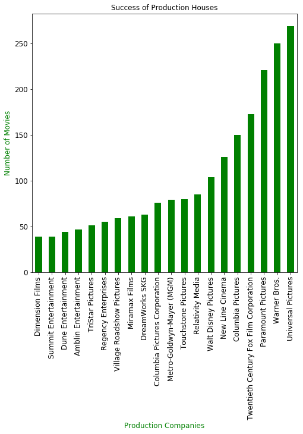

```python
prod_new= seperator('production_companies').head(20)
prod_new.sort_values(ascending = True, inplace = True)
#initializing plot
mf = prod_new.plot.bar(color = 'green', fontsize = 12)
#Title for the plot.
mf.set(title = 'Success of Production Houses')
#Setting the label names.
mf.set_ylabel('Number of Movies', color = 'g', fontsize = '12')
mf.set_xlabel('Production Companies',color='g',fontsize = '12')
mf.figure.set_size_inches(8,8 )
plt.show()
```

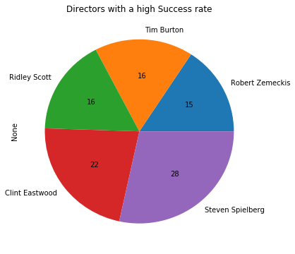

```python
prod_new= seperator('director').head(5)
prod_new.sort_values(ascending = True, inplace = True)
#initializing plot
mf = prod_new.plot.pie(autopct='%i')
#Title for the plot
mf.set(title = 'Directors with a high Success rate')
mf.figure.set_size_inches(6,6)
plt.show()
```

From the above graphs, one can see who are the best in the business. From production houses to directors and finally to cast , I can see the guys listed above were the successfull ones in making,directing and starring in Box office Hits.

## Conclusions

This dataset has been analyzed to find out some critical components to make a movie Successfull. I have analyzed the data by keeping in mind the factors which make a movie to gain success at the BO. The factors considered by me were - Review Ratings, Profit, Cast, Director and Production Houses. I considered review ratings because most of the people nowadays have developed a tendency to watch a movie only after checking out the reviews. So I used it to find the distribution of movies and their corresponding review ratings. I also used runtime to get the review ratings.

Another thing i did was to calculate the profits each movie made. I found out the movies with High and low profit so that i can distinguish easily. Profit was calculated as a measure of budget and revenue.

The final thing was to find the best persons and companies who can deliver a Sucessful film. Thus I created a dataframe which contained records with revenue more than the budget. Thus from this data I was able to derive at a conclusion to which were the best components that can be arranged to make a commercially successfull movie.

## Limitations

Although I have analyzed all the essential factors for a sucessfull movie , I would like to say that this might have its limitations. We can extend this analysis by focusing on factors such as Runtime, Release date and Release year. The evidences I have provided here will not fully guarantee success. While concluding it a famous proverb came to my mind "Too many cooks spoil the broth". Likewise having the best doesnt guarantee that it will end up in the best way only. I would like to say that the analysis I provided will work on numerous occassions but not on all. I would like to add that I only took some factors into consideration and not every available thing.

That's the end of my conclusion. Curtains Down!